# Introduction

Hello, I am currently writing about correlations between time spent playing video games and issues that people may run into when it comes to grades. While it may not necessarily be that large of a correlation as my data set that I am introducing does not include any external factors, I just want to see if there any any correlations when it comes to gaming itself. There are no necessarily negative or positive connotations that I am specifically looking to answer but simply trying to show some interesting developments within the data set, as well as any particular hypthesis that we can conclude from such a thing.

## Code Resource and Uploading

So, I recieved this data from https://www.kaggle.com/datasets/willianoliveiragibin/games-and-students, which is a great resource but honestly, I am writing this on a brain cell and a dream. The CSV for the file is named, and I did rename it, "gameandgrade", which for the sake of my own mental health and your own, I will refer to the specific file as G&G. It is almost certain that I say gaming and grades at some given point, and I don't want to confuse anyone.

So, to start this off, make sure you import panda, which if this copies and pastes correctly, you will see me do below.

```python
%pip install pandas
%pip install matplotlib
```

```python
import pandas as pd
import matplotlib.pyplot as plt
```

Now that pandas is install, I apologize for any weird graphs, this is my first time using pandas and I want you all to know that I am doing my best. Now, there are a few coloumns within the data, though some of it is primarily information about the people who were questioned within the original data gathering of the dataset, so while there are things like school code, gender, pieces of information that are specific to the person, I am not going to utilize that. Primarily because someone's gender, their parent's education, and school code, does not matter to the sort of research that I am doing. Perhaps it could have some minor effects but when it comes down to debates on gaming and grades, HA! I told you I would say it, gender, specification in schools, and a parent's education is not something that comes up often.

```python
df = pd.read_csv("gameandgrade.csv")
```

So, I made sure that pandas is properly installed, that is is imported properly, and that it has read the csv as well. If you are using VSCode and don't have all the pandas and python extensions installed, please make sure that you do, it totally did not take two to three class periods to make sure everything was here, I said nothing of the such.

# Pre-Processing and Steps

Once again, I must preface again that I am still new to everything that I am doing, so I really apologize for any mistakes that I do, that I do things in an unoptimized way, and please trust in the process as well. If you are new like me, you definently got this!

So the first thing we are going to check is all the coloumns that are in the dataset, if for some reason I mess up with uploading the coding section, send me hopes and prayers because I will cry. Anyway, you are going to want to use "df.coloums", which will pull out the coloumns of data, and if it turns out that I am a madman and speaking in languages that are no longer known to man, let my rambles be the last of me, allow my words to echo in thi--, okay, I am done being dramatic now.

```python
df.columns
```

```
Index(['Sex', 'School Code', 'Playing Years', 'Playing Often', 'Playing Hours',
       'Playing Games', 'Parent Revenue', 'Father Education',
       'Mother Education', 'Grade', 'percentage'],
      dtype='object')
```

So, we have a total of eleven categories for the data collected, of course parental revenue is not going to affect whether or not someone is passing or failing a class. I just got an early action warning because I am failing my stats class, is it because I have been playing video games? No, it's called being a broke college student doing multiple opening to closing shifts within the past couple of days, it's called exhaustion and being tired when you get home. Some teachers should just invest in a more open grading policy. The education of your parents does not mean that you will develop specific habits either, just because your dad is a plumber does not mean you suddenly have an interest in copper pipes and his decent wage will pay for your copper pipe addiction. In the case that your father walked out, don't worry, mine did too. Does not mean I abandon my responsibilites. Next we do not need to know what gender someone is nor their school code, that gets a little too stalker-ish but that clearly didn't stop this person from gathering that data. I will now check if there are any nulls in the dataset.

```python
df.isnull().sum()
```

```
Sex                 0
School Code         0
Playing Years       0
Playing Often       0
Playing Hours       0
Playing Games       0
Parent Revenue      0
Father Education    0
Mother Education    0
Grade               0
percentage          0
dtype: int64
```

Well thankfully, there are no nulls, I totally didn't have to play around with pandas for a solid three minutes. You are not the judge of me. Onto the next step, getting a histogram.

```python
df.info
```

[output not shown]

[output cut: 25 more lines]

```python
df.describe
```

[output not shown]

[output cut: 25 more lines]

```python
df.dtypes
```

```
Sex                  int64
School Code          int64
Playing Years        int64
Playing Often        int64
Playing Hours        int64
Playing Games        int64
Parent Revenue       int64
Father Education     int64
Mother Education     int64
Grade               object
percentage          object
dtype: object
```

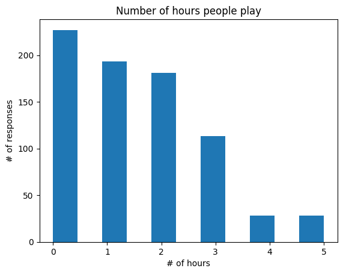

```python
pTime = df['Playing Hours']
plt.hist(pTime, bins=11)
plt.xlabel("# of hours")
plt.ylabel("# of responses")
plt.title("Number of hours people play")

plt.show()
```

So, I tried my best with seperating the coloumns, if I went with something larger than eleven, the graph kind shaped weirdly. Aside from what, we see that there are a lot of non-gamers in this gamer dataset. These plebians actually have a life instead of spending their time, inside the house, growing virtual vegtables, getting virtual money, and a virtual wife. Imagine that! Unlike you, they actually touch grass, but that's fine, at least Abigal from Stardew Valley loves you, sometimes. Though now we have to focus on the typical grades, which will hopefully not be as skewed as this graph.

[figure not shown]

```python
gradGraph = df['Grade']
plt.hist(gradGraph, bins=100)
plt.xlabel('Grades')
plt.ylabel('# of responses')
plt.title('Student grades')
plt.show()
```

So, obivously, I am not gonna expect you to be able to read that. I am not completely insane, I am just partially insane, and no, that's not because I have an addiction to Stellaris. It is because I have an addiction to Stellaris that I am even here and am able to undertstand a good chunk of what I am saying. So I am going to do what is called, a pro gamer move and just try to figure out how to grab the top 20 gamer's grades, no, that was not grammatically correct and I have no clue how to adjust that sentence for it to be correct.

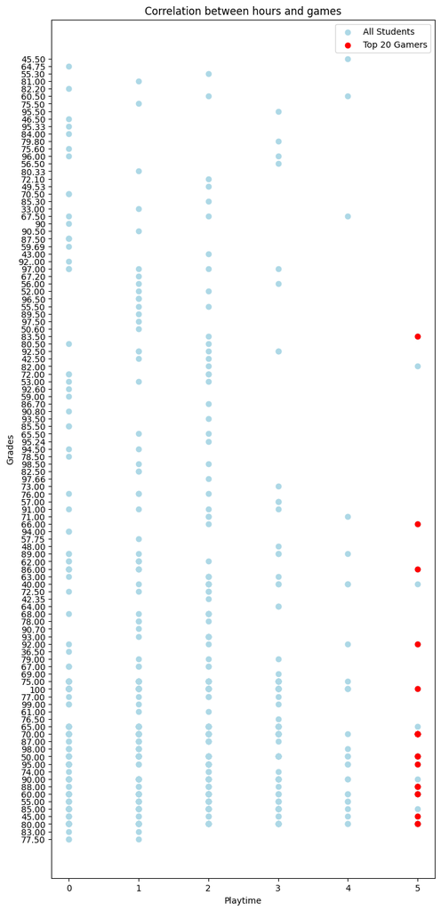

```python
top20 = df.sort_values(by='Playing Hours', ascending=False).head(20)
plt.figure(figsize=(8,18))
plt.scatter(df['Playing Hours'], df['Grade'], color='lightblue',label='All Students')
plt.scatter(top20['Playing Hours'], top20['Grade'], color='red', label='Top 20 Gamers')
plt.xlabel('Playtime')
plt.ylabel('Grades')
plt.title('Correlation between hours and games')
plt.legend()
plt.show()
```

## Resources

G&G, Games and Grades, https://www.kaggle.com/datasets/willianoliveiragibin/games-and-students/data